# Approximating $\pi$ from Human Trajectories in a Video Game

Approximating $\pi$ (~3.14159265358979323846) has been a task of immense interest for humans. There have been many ingenious methods to calculate $\pi$. Here, we explore a new one -- Can we approximate $\pi$ from human actions as they try to move in circles in a video game?

The answer is, of course, yes. Where there are circles, there must be $\pi$. In this work, we build upon one of the earliest methods humans developed to approximate $\pi$ from player trajectories. Archimedes had observed that, with an increasing number of sides (n), regular n-sided polygons become increasingly better approximations of circles. This simple observation led him to develop one of the earliest methods to calculate $\pi$ as the ratio between the perimeter of the n-polygon and its largest diagonal.

In this page, we will look at its application in estimating $\pi$ from human trajectories in a video game. The game our human players played is Space Fortress (Mane and Donchin, 1989). The game was developed as a common complex task for several different research groups studying complex task learning. Even after more than 3 decades, the game is still widely used as an experimental paradigm to study complex task learning (e.g., Gray & Lindstedt, 2017; Anderson et al, 2019; Rahman & Gray, 2020; 2021) and been the testbed for numerous theories of human decision-making and learning. Recently, it has also been thrown as a challenge for reinforcement learning agents (Agarwal, Hope, & Sycara, 2019). As we will see, although the flight paths taken by our players are not regular polygons, this ratio can still be used to approximate $\pi$ for each full circle around the Fortress.

In the game, players fly a ship in circles around the enemy HQ (i.e., the Space Fortress) and attack to destroy it. The optimal path is circles, which our players have been informed of. But, it is difficult to implement. The game controls dictate that the players have to construct the circles with straight lines. In other words, they have to approximate circles with polygons. A direct consequence is -- the better the polygons are as approximations of circles (which equates to, the higher number of straight lines as the sides of the polygons), the better would be the approximations of $\pi$ according to Archimedes' method to approximate $\pi$. Another way to look at it: Approximations of $\pi$ provides a measure of performance in moving in circles.

These results have been presented and published at the $19^th International Conference on Cognitive Modeling (ICCM). The full paper (Rahman & Gray, 2021) can be found here: https://iccm-conference.neocities.org/2021/papers/612.pdf

Finally, we take a few minutes to marvel at the simple beauty of Archimedes' method and have some fun with it. Combining our knowledge of calculus, we devise a simple way to approximate $\pi$ to many digits using just our computers or, if needed, using a pocket calculator. This exercise is meant mostly for fun, but may come in handy if we find ourselves in need to quickly but accurately approximate $\pi$ in a doomsday situation with aliens invading us and we have no internet. We also discuss why this method worked in approximating $\pi$ from the actions of our human players.

## Dataset description

This dataset contains highly detailed records of nine individuals' performance in the game of Space Fortress over 31 hours at the CogWorks Lab (directed by Wayne D. Gray) at Rensselaer Polytechnic Institute. Each individual played 8 games in each 1-hr session per day for 31 days, resulting in total 248 games per player. For our analysis, we exclude the first day's data (i.e., the first 8 games) as the participants needed some time to get familiar with the rules and the controls of the game.

The dataset was collected by Marc Destefano as a part of his thesis (Destefano, 2010) during his PhD in Cognitive Science from Rensselaer Polytechnic Institute. Due to the enormous richness of the data, it has been studied in several works (Destefano & Gray, 2016; Gray & Lindstedt, 2017; Rahman & Gray, 2020), focusing on individual performance and learning at many different scopes of the complex task; such as, different levels of task, different timescales, in part- or sub-tasks vs whole task, individual learning curves vs group-averaged learning curves.

More details can be found in this open-source repository for the dataset in osf.io: https://osf.io/v5mzx/. Please note that, while the entire dataset can be downloaded from OSF, the "Complete21June2024_pickle.txt" file available on OSF contains summary of all games played by all individuals and is sufficient to reproduce all calculations here.

## Approximations of $\pi$ from the Circular Paths of Player Ship

Why use Archimedes' Method to Approximate $\pi$ here? Archimedes' method relies on approximating circles with regular n-sided polygons. In other words, the circles are constructed with n equal-sized lines, which closely resembles how the players construct the circles in Space Fortress -- using many small lines.

But why do the players need to move in circles in this game? The game of Space Fortress was developed by Mane and Donchin (1989) as a complex game to test human limits and use it as a common experimental paradigm to study complex task or skill learning. In this game, the player battles the Space Fortress -- which lines at the center of the screen -- by flying a ship around it and periodically shooting at it. Moving in circles around the Fortress is the optimal flight strategy as it helps in both minimizing risk of getting hit and maximizing opportunities to shoot at the Fortress (Frederiksen & White, 1989; Rahman and Gray, 2021).

The need to construct the circles with many small lines stems from the constraints imposed in SF’s input system: a player can either move the ship along straight lines (using "Thrust" key) or rotate (using "Rotate" key) to change ship direction, but cannot simultaneously use both to move at angles. To obtain a circular path (and to attack the enemies), a player needs to periodically repeat a sequence of keypresses throughout the game: Thrust-Rotate-(Shoot at Fortress). These movement constraints mean that the players need to construct the circles with numerous straight lines.

We calculate $\pi$ for each circle completed around the Fortress. So the Fortress is the center of every one of our circles. To get $\pi$, we want to use this simple relationship: S = $2\pi*r \Rightarrow \pi = \frac{S}{2r}$. For n-polygons, $s$ is the perimeter of the polygon and $r$ is half of the diagonal. In Space Fortress, $s$ is the distance traveled by the ship in each circle and for $r$, we can use the average distance of the player ship from the Fortress. These values were calculated for the (x,y) coordinates of ship location against time, as shown below in the code. Briefly, we calculate the length of each linear step taken by the player and calculate the Euclidean distance between the ship and the Fortress at each point a new line starts (i.e., a new press of the "thrust" key).

```python
# %matplotlib widget
%matplotlib inline
# %matplotlib notebook
# %matplotlib ipympl

import numpy as np
import pandas as pd
import matplotlib
import matplotlib.pyplot as plt
import matplotlib.animation as animation
import seaborn as sns
plt.rcParams["figure.figsize"] = (15,12)
# sns.set(rc = {'axes.grid':False})
sns.reset_orig()
sns.set(style = 'ticks', font ='serif', font_scale = 1.2)
sns.color_palette("husl", 9)


import copy
import time
# %matplotlib notebook
# from IPython.display import HTML
# plt.rcParams["animation.html"] = "jshtml"
```

```python
# For later: Illustration of Archimedes' method

# coord = [[1,1], [2,1], [2,2], [1,2], [0.5,1.5]]
# coord.append(coord[0]) #repeat the first point to create a 'closed loop'

# xs, ys = zip(*coord) #create lists of x and y values

# plt.figure()
# plt.plot(xs,ys)
# plt.show()
```

```python
# ------------------- Some conveneient Functions ----------------------------

# Euclidean distance between two points
def eu_distance(x1, y1, x2, y2):
	d = np.sqrt((x1-x2)**2 + (y1-y2)**2)
	return(d)

# Convert polar co-ordinates to complex numbers of form z = r*e^\theta
def polar2z(r,theta):
    return r * np.exp( 1j * theta )

# Version 1: Convert complex numbers of form z = r*e^\theta to z = (r, theta)
	# using defaults for angle, returns angle between -pi to pi or -180 to 180
def z2polar1(z):
    return ( np.abs(z), np.angle(z) )

# Version 2: Convert complex numbers of form z = r*e^\theta to z = (r, theta)
	# with my tweaks, returns angle between 0 to 2*pi or 0 to 360
def z2polar2(z):
    angles = np.angle(z) # default return within -pi to pi
    # here, we implement an if condition: if the angle is negative, add 2pi with the angle
    angles[angles<0] = angles[angles<0] + 2*np.pi
    return ( np.abs(z),  angles)


# ------------------- Load data and calculate parameters ----------------------

# For conversion of units and relative locations
convert_radtodeg = 180/np.pi
fortress_x = 355 # Actual location of Fortress on Screen.
fortress_y = 315

# Some placeholders
pi_all = []
pi_per_game = np.zeros([248,1])
mean_r_per_game = np.zeros([248,1])
total_d_per_game = np.zeros([248,1])

game_list = np.arange(9,249) # We exclude the first 8 games

fresh_calculate_pi = 0 # Make it 1 for a fresh calculation of pi. ***************************

if (fresh_calculate_pi):

	# ------------------- LOAD DATA -----------------------------
	agg_df = pd.read_pickle("Complete21June2024_pickle.txt")

	# -------------- Calculate Pi per cycle around the Fortress -------------------

	# Later we will average them over cycles to get game-wise approximations of Pi
	num_players = 9

	for player in range(1, num_players + 1):


		colors = ['red', 'blue','green']
		game_i = 0

		for ov_game_number in game_list:
			if ((player == 4) & (ov_game_number in [57, 59, 116, 118, 215])): # Conditions to skip over some missing data for Player 4
				pi_per_game[ov_game_number] = np.nan
				continue
			print(player, ov_game_number)

			# get index of row for the given player and the game number
			index_in_agg_df = agg_df.loc[(agg_df.pid == player) & (agg_df.game == ov_game_number)].index[0]

			# Get locations as x and y arrrays. We have the locations relative to Fortress (i.e., the Fortress is at the origin (x = 0, y = 0))
			x = pd.Series(agg_df.loc[index_in_agg_df, "X_arr"])
			y = pd.Series(agg_df.loc[index_in_agg_df, "Y_arr"])

			# It may help to have it in (a) polar and (b) complex number form
			# Expecially as we deal with the angle changes to estimate angular velocity
			r, theta = z2polar2(x+1j*y)


	# ---------------------------- Calculcting Pi PER CYCLE ---------------------------------------------------

			# # We get the cycle breaks by using the criterion: y turns positive->negative
			# # Which translates to: (y.shift())&(y<0)
			# interpretation: We are using the y = 0 line as the divider, from one particular direction.

			cycle_breaks = np.where((y<0) & (y.shift() >0))[0]
			num_cycles = cycle_breaks.shape[0]
			total_d_cycle = np.zeros([num_cycles,1])
			mean_r_cycle = np.zeros([num_cycles,1])
			pi_cycle = np.zeros([num_cycles,1])

			cycle_start_i = 0
			cycle_end_i = 0

			for cy_break_i in np.arange(num_cycles):
				cycle_end_i = cycle_breaks[cy_break_i]
				x_cycle = x[cycle_start_i:cycle_end_i]
				y_cycle = y[cycle_start_i:cycle_end_i]
				a = x_cycle
				b = y_cycle # ??
				d_cycle = np.sqrt((a - a.shift())**2+(b - b.shift())**2)
				total_d_cycle[cy_break_i] = np.nansum(d_cycle)
				mean_r_cycle[cy_break_i] = np.mean(np.sqrt(a**2+b**2))
				pi_cycle[cy_break_i] = total_d_cycle[cy_break_i]/2/mean_r_cycle[cy_break_i]  # ***************************************
				# print(total_d_cycle[cy_break_i], mean_r_cycle[cy_break_i], pi_cycle[cy_break_i])
				pi_all.append(pi_cycle[cy_break_i])
				cycle_start_i = cycle_end_i
			# print(pi_cycle)

			# Store data in agg_df
			agg_df.loc[index_in_agg_df, "mean_r_per_cycle"] = mean_r_cycle
			agg_df.loc[index_in_agg_df, "total_d_per_cycle"] = total_d_cycle
			agg_df.loc[index_in_agg_df, "pi_per_cycle"] = pi_cycle

	agg_df["pi_per_game"] = agg_df.pi_per_cycle.apply(np.mean)

else:
    agg_df = pd.read_pickle("Complete21June2024_pickle.txt") # Actually the same file. But we have already saved the values of mean r, total distance, and pi
```

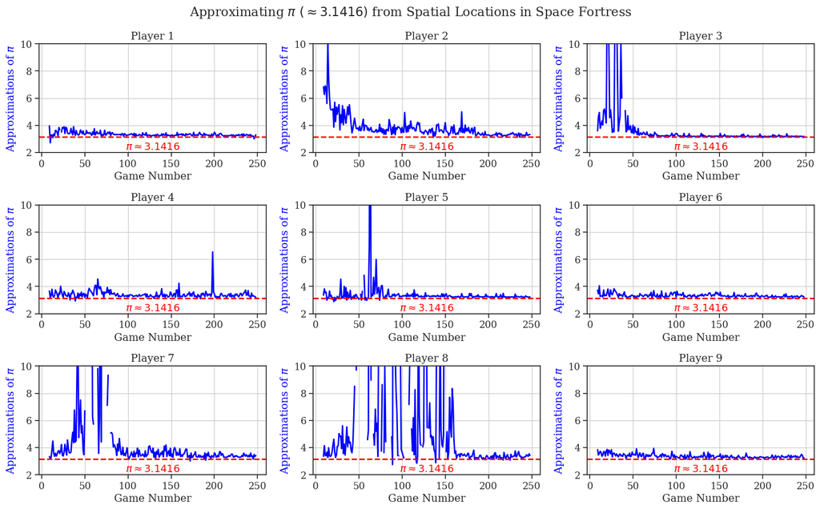

```python
num_rows = 3
num_cols = 3
fig, axs = plt.subplots(num_rows, num_cols, figsize = (16, 10))

for player in range(1,10):
    fig_ix, fig_iy = int((player-1)/num_rows), (player-1)%num_cols
    ax = axs[fig_ix, fig_iy]
    to_plot = agg_df.loc[(agg_df.pid == player) & (agg_df.game >= 9)]
    # print(to_plot.game)

    ax.plot(to_plot["game"].values, to_plot["pi_per_game"].values, lw = 2, color = "blue")
    ax.axhline(y = 3.1416, color = 'red', ls = "--", lw = 2)
    ax.grid()
    ax.text(0.5, 0.05, r"$\pi \approx 3.1416$", color = 'red',
         transform = ax.transAxes, fontsize=14, verticalalignment='center', horizontalalignment = 'center',bbox= None)
    ax.set_xlabel("Game Number")
    ax.set_ylabel(r"Approximations of $\pi$", color = "blue")
    ax.set_title("Player %i"%player)
    ax.set_ylim([2, 10])

plt.suptitle(r"Approximating $\pi\ (\approx 3.1416)$ from Spatial Locations in Space Fortress")
fig.tight_layout()
plt.show()
plt.close()
```

### Zooming in

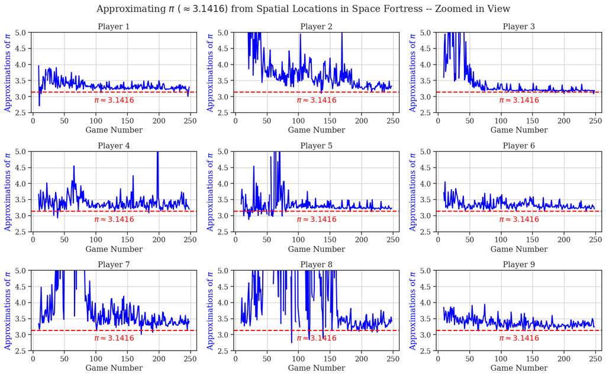

```python
num_rows = 3
num_cols = 3
fig, axs = plt.subplots(num_rows, num_cols, figsize = (16, 10))



for player in range(1,10):
    fig_ix, fig_iy = int((player-1)/num_rows), (player-1)%num_cols
    ax = axs[fig_ix, fig_iy]
    to_plot = agg_df.loc[(agg_df.pid == player) & (agg_df.game >= 9)]
    # print(to_plot.game)

    ax.plot(to_plot["game"].values, to_plot["pi_per_game"].values, lw = 2, color = "blue")
    ax.axhline(y = 3.1416, color = 'red', ls = "--", lw = 2)
    ax.grid()
    ax.text(0.5, 0.15, r"$\pi \approx 3.1416$", color = 'red',
         transform = ax.transAxes, fontsize=14, verticalalignment='center', horizontalalignment = 'center',bbox= None)
    ax.set_xlabel("Game Number")
    ax.set_ylabel(r"Approximations of $\pi$", color = "blue")
    ax.set_title("Player %i"%player)
    ax.set_ylim([2.5, 5])

plt.suptitle(r"Approximating $\pi\ (\approx 3.1416)$ from Spatial Locations in Space Fortress -- Zoomed in View")
fig.tight_layout()
plt.show()
plt.close()
```

## Results and Discussion

There are some interesting points to notice about the changes in the $\pi$ approximations with learning.

1. For all individuals, the approximations became quite to the true value of $\pi$ towards the end of practice. Isn't it quite remarkable how good those approximations become? The improvement of the approximations show that the players improved in controlling the ship and moving in more circular paths around the Fortress.
2. But, the nine players also show a high amount of individual differences in the learning curves. Some players (such as numbered 3, 7, and 8), the approximations become quite inaccurate a period. These periods of worse $\pi$ approximations often coincided with the players adopting paths other than circles, as verified by replaying particular games. However, we also found that other method changes also resulted in the approximations getting worse, which indicates losses of control over the ship as new strategies were explored or adopted.
3. For some individuals (e.g., Players 1, 4, 6, and 9), the approximations were very close to the true value from the beginning of learning and remained predominantly close throughout except for a few exceptions (e.g., in case of Player 4).

Generally, we see that the approximations provide quite a sensitive measure of flight performance. As we demonstrated in Rahman and Gray (2021), the game scores that represent flight control and has been used in most studies of Space Fortress, falls well short of our $\pi$ approximations in capturing the improvements with learning. A great strength of this measure is that we know what the asymptote of performance is -- the true value of $\pi$. Moreover, there is very little random chance that the approximations would improve without improved flight skills as (1) no path other than circles would improve the approximations and (2) to improve, the players need smaller and higher number of lines in constructing the circles. Therefore, improvements of the approximations can be taken as a true sign of improvement of flight control without any ambiguity.

Another benefit is that we obtain a measure that inform us of the changes in methods or strategies of gameplay. Flight skills are fundamental to playing Space Fortress and the players need to have commensurate flight skills to device execute attack or defense strategies. We discussed some examples in Rahman and Gray (2020) and Rahman (2022).

Finally, we do not mean that this one measure is sufficient to capture the global skill in Space Fortress, a very complex game that requires combining multiple skills together to master. The approximations of $\pi$ provide a good measure for the fundamental skill of flight control that serves a foundation for the complex skill of beating the Space Fortress.

## Appendix: A Compact Formulation of Archimedes' Method using Calculus

Needless to say, Archimedes did not have access to our knowledge of Calculus. But his method to approximate $\pi$ captures the essence of Calculus quite literally -- we break it down to build it back up. Specifically, we use the number of sides of the polygons (i.e., $n$) as the limiting variable; as $n$ approaches infinity, our approximation converge to the "true" value of $\pi$ even though we cannot ever know the exact value. So, we can start by writing -- $$ \pi = \lim_{n \rightarrow \infty} \frac{perimeter\ of\ the\ polygon}{length\ of\ the\ largest\ diagonal} $$

End result: $$ \pi = \lim_{n \rightarrow \infty} n*sin(\frac{\pi}{n}) $$

```python
def pi_archimedes(n):
    return n*np.sin(np.pi/n)

true_pi_upto_20_digits = "3.14159265358979323846"

print ("Number of sides (n)\t Approximated pi\t True pi upto 20 digits")
for n in range(4, 100000):
    if (n%1000 == 0): print(n, "\t\t\t", pi_archimedes(n), "\t", true_pi_upto_20_digits)
```

```
Number of sides (n)	 Approximated pi	 True pi upto 20 digits
1000 			 3.1415874858795636 	 3.14159265358979323846
2000 			 3.141591361661758 	 3.14159265358979323846
3000 			 3.1415920793995156 	 3.14159265358979323846
4000 			 3.1415923306077547 	 3.14159265358979323846
5000 			 3.141592446881286 	 3.14159265358979323846
6000 			 3.1415925100422175 	 3.14159265358979323846
7000 			 3.141592548126268 	 3.14159265358979323846
8000 			 3.141592572844282 	 3.14159265358979323846
9000 			 3.14159258979087 	 3.14159265358979323846
10000 			 3.141592601912665 	 3.14159265358979323846
11000 			 3.141592610881423 	 3.14159265358979323846
12000 			 3.1415926177028983 	 3.14159265358979323846
13000 			 3.141592623011611 	 3.14159265358979323846
14000 			 3.1415926272239116 	 3.14159265358979323846
```

[output cut: 85 more lines]

## References

Link to dataset available open-source: https://osf.io/v5mzx/

Agarwal, A., Hope, R., & Sycara, K. (2019, October). Learning context-sensitive strategies in space fortress. In *2019 28th IEEE International Conference on Robot and Human Interactive Communication (RO-MAN)* (pp. 1-7). IEEE.

Anderson, J. R., Betts, S., Bothell, D., Hope, R., & Lebiere, C. (2019). Learning rapid and precise skills. *Psychological review, 126*(5), 727.

Destefano, M. (2010). *The mechanics of multitasking: The choreography of perception, action, and cognition over 7.05 orders of magnitude (Publication No. 751326397)* [Doctoral dissertation, Rensselaer Polytechnic Institute]. ProQuest Dissertations and Theses database.

Destefano, M., & Gray, W. D. (2016). Where should researchers look for strategy discoveries during the acquisition of complex task performance? The case of Space Fortress. In *Proceedings of the 38th annual conference of the Cognitive Science society* (pp. 668–673). Cognitive Science Society.

Frederiksen, J. R., & White, B. Y. (1989). An approach to training based upon principled task decomposition. *Acta Psychologica, 71* (1-3), 89–146.

Gray, W. D., & Lindstedt, J. K. (2017). Plateaus, dips, and leaps: Where to look for inventions and discoveries during skilled performance. *Cognitive Science, 41*(7), 1838–1870.

Mané, A., & Donchin, E. (1989). The space fortress game. *Acta Psychologica, 71*(1-3), 17–22.

Rahman, R., & Gray, W. D. (2020). Spotlight on dynamics of individual learning. *Topics in Cognitive Science, 12*(3), 975–991

Rahman, R., & Gray, W. D. (2021). Towards precise measures of individual performance in complex tasks. In T. C. Stewart (Ed.), *Proceedings of the 19th international conference on cognitive modeling* (pp. 227–233). Applied Cognitive Science Lab, Penn State

Rahman, R. (2022). *Dynamics of Individual Learning* (Publication No. 2718583605) [Doctoral dissertation, Rensselaer Polytechnic Institute]. ProQuest Dissertations and Theses database.